# Tarea 4: regresión logística

En esta tarea construiremos varios modelos de regresión logística y compararemos sus resultados.

### Preparación

Puedes usar el siguiente código, o tus implementaciones propias:

```r
source("tarea_4_codigo.R")
```

Revisa las funciones que están ahí. Son las que usamos en clase.

Usaremos los datos de sobrevivientes del hundimiento del Titanic, obtenidos de [este concurso de Kaggle](https://www.kaggle.com/c/titanic)

```r
library(tidyverse)
datos_titanic <- read_csv("./tarea_4_datos/train.csv")
```

En este caso, queremos predecir la variable *Survived* en términos del resto. Para simiplificar el ejericicio,

- solo usaremos alguna de las variables,
- ignoramos datos faltantes en la variable edad

```r
datos_titanic <- datos_titanic %>% select(Survived, Pclass, Age, Sex, Embarked) %>%
  filter(!is.na(Age), !is.na(Embarked))
summary(datos_titanic)
```

```
    Survived          Pclass          Age            Sex
 Min.   :0.0000   Min.   :1.00   Min.   : 0.42   Length:712
 1st Qu.:0.0000   1st Qu.:1.00   1st Qu.:20.00   Class :character
 Median :0.0000   Median :2.00   Median :28.00   Mode  :character
 Mean   :0.4045   Mean   :2.24   Mean   :29.64
 3rd Qu.:1.0000   3rd Qu.:3.00   3rd Qu.:38.00
 Max.   :1.0000   Max.   :3.00   Max.   :80.00
   Embarked
 Length:712
 Class :character
 Mode  :character
```

```r
head(datos_titanic)
```

| Survived | Pclass | Age | Sex | Embarked |
| --- | --- | --- | --- | --- |
| 0 | 3 | 22 | male | S |
| 1 | 1 | 38 | female | C |
| 1 | 3 | 26 | female | S |
| 1 | 1 | 35 | female | S |
| 0 | 3 | 35 | male | S |
| 0 | 1 | 54 | male | S |

La descripción de las variables es:

survival Survival 0 = No, 1 = Yes pclass Ticket class 1 = 1st, 2 = 2nd, 3 = 3rd sex Sex Age Age in years  
embarked Port of Embarkation C = Cherbourg, Q = Queenstown, S = Southampton

Convertimos las variables categóricas a numerícas creando indicadoras, como sigue:

```r
datos <- datos_titanic %>%
  mutate(female = as.numeric(Sex == "female"),
         southampton = as.numeric(Embarked == "S"),
         cherbourg = as.numeric(Embarked == "C")) %>%
  select(-Embarked, -Sex)
datos
```

| Survived | Pclass | Age | female | southampton | cherbourg |
| --- | --- | --- | --- | --- | --- |
| 0 | 3 | 22.00 | 0 | 1 | 0 |
| 1 | 1 | 38.00 | 1 | 0 | 1 |
| 1 | 3 | 26.00 | 1 | 1 | 0 |
| 1 | 1 | 35.00 | 1 | 1 | 0 |
| 0 | 3 | 35.00 | 0 | 1 | 0 |
| 0 | 1 | 54.00 | 0 | 1 | 0 |
| 0 | 3 | 2.00 | 0 | 1 | 0 |
| 1 | 3 | 27.00 | 1 | 1 | 0 |
| 1 | 2 | 14.00 | 1 | 0 | 1 |
| 1 | 3 | 4.00 | 1 | 1 | 0 |

[output cut: 702 more lines]

Consierando cómo se ven estos datos, podemos usar una normalización simple (puedes también hacerlo como lo hicimos en clase), de forma que todas las variables estén aproximadamente en el rango 0 - 1 :

```r
datos$age_n <- datos$Age / 60
datos$pclass_n <-(datos$Pclass - 1) / 3
datos_trans <- datos %>% select(Survived, pclass_n, age_n, female, southampton, cherbourg)
datos_trans
```

| Survived | pclass_n | age_n | female | southampton | cherbourg |
| --- | --- | --- | --- | --- | --- |
| 0 | 0.6666667 | 0.36666667 | 0 | 1 | 0 |
| 1 | 0.0000000 | 0.63333333 | 1 | 0 | 1 |
| 1 | 0.6666667 | 0.43333333 | 1 | 1 | 0 |
| 1 | 0.0000000 | 0.58333333 | 1 | 1 | 0 |
| 0 | 0.6666667 | 0.58333333 | 0 | 1 | 0 |
| 0 | 0.0000000 | 0.90000000 | 0 | 1 | 0 |
| 0 | 0.6666667 | 0.03333333 | 0 | 1 | 0 |
| 1 | 0.6666667 | 0.45000000 | 1 | 1 | 0 |
| 1 | 0.3333333 | 0.23333333 | 1 | 0 | 1 |
| 1 | 0.6666667 | 0.06666667 | 1 | 1 | 0 |

[output cut: 702 more lines]

Y finalmente, separa en entrenamiento y prueba de esta forma (como estamos normalizando con cantidades fijas, no tenemos que normalizar por separado):

```r
set.seed(2850)
datos_trans <- datos_trans %>%
  mutate(u = runif(nrow(datos_trans)))
entrena <- datos_trans %>% filter(u <= 0.7) %>% select(-u)
prueba <- datos_trans %>% filter(u > 0.7) %>% select(-u)
```

```r
nrow(entrena)
```

```
[1] 512
```

```r
nrow(prueba)
```

```
[1] 200
```

```r
x_ent <- as.matrix(entrena %>% select(-Survived))
x_pr <- as.matrix(prueba %>% select(-Survived))
y_ent <- entrena$Survived
y_pr <- prueba$Survived
```

### Ejercicio A

1. Ajusta un modelo usando solo una variable (por ejemplo, el indicador si abordó en cherbourg). Ajusta el tamaño de paso y checa convergencia

```r
x_ent_1 <- x_ent[ , "cherbourg", drop = FALSE] # drop=false es para no convertir en vector
devianza_ent <- devianza_calc(x_ent_1, y_ent)
grad_ent <- grad_calc(x_ent_1, y_ent)
## termina esta línea para descenso en gradiente
n <- 10000
z <- descenso(n = n, z_0 = rep(0, 2), eta = 0.00001, h_deriv = grad_ent)
```

2. Calcula ahora la devianza de prueba de este modelo

```r
# termina esta línea
devianza_pr(z[n,])
```

```
[1] 266.9904
```

La devianza de prueba es 266.99.

3. Para este modelo simple, calcula la probabilidad estimada por el modelo de sobrevivir para una persona que embarcó en cherbourg y una que no:

```r
# Rellena:
# probabilidad sobrevivir si no embarcó en Cherbourg
h(z[n,]%*%c(1,0))
```

```
          [,1]
[1,] 0.3550725
```

### Ejercicio B

Ahora utiliza todas las variables, y repite el ejercicio anterior:

1. Ajusta un modelo usando solo una variable (por ejemplo, el indicador si abordó en cherbourg). Ajusta el tamaño de paso y checa convergencia

```r
devianza_ent(z[n,])
```

```
[1] 577.4331
```

2. Calcula ahora la devianza de prueba de este modelo

```r
devianza_pr(z[n,])
```

```
[1] 216.4917
```

La devianza de prueba es 216.5 .

3. Calcula la probabidad estimada de que un hombre con boleto de 3a clase, de 60 años, que abordó en southampton sobreviva. Repite para una mujer con boleto de 1a clase, de 60 años, que abordó en southampton

```r
# Mujer de 60 años en primera clase southhampton
h(z[n,]%*%c(1,0,1,1, 1,0))
```

```
          [,1]
[1,] 0.5371267
```

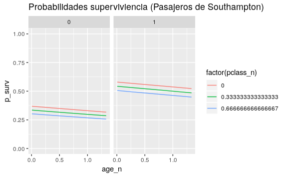

¿Cuáles son las probabilidades más altas? ¿Cuáles son las más bajas?

```r
# Probabilidades más bajas
  dat_calc %>%
  dplyr::arrange(p_surv) %>%
  glimpse
```

```
Observations: 486
Variables: 6
$ pclass_n    <dbl> 0.6666667, 0.6666667, 0.6666667, 0.6666667, 0.6666667, ...
$ age_n       <dbl> 1.3333333, 1.2333333, 1.1833333, 1.1750000, 1.1666667, ...
$ female      <dbl> 0, 0, 0, 0, 0, 0, 0, 0, 0, 0, 0, 0, 0, 0, 0, 0, 0, 0, 0...
$ southampton <dbl> 1, 1, 1, 1, 1, 1, 1, 1, 1, 1, 1, 1, 1, 1, 1, 1, 1, 1, 1...
$ cherbourg   <dbl> 0, 0, 0, 0, 0, 0, 0, 0, 0, 0, 0, 0, 0, 0, 0, 0, 0, 0, 0...
$ p_surv      <dbl> 0.2566220, 0.2599259, 0.2615881, 0.2618658, 0.2621437, ...
```

5. ¿Cuál de los dos modelos anteriores (una sola variable, todas las variables) se desempeña mejor? ¿Por qué?

El segundo, por que la devianza de prueba es menor.

6. Calcula el error de clasificación de prueba

```r
mean(abs(prueba$Survived - round(h(cbind(1,x_pr)%*%beta))))
```

```
[1] 0.175
```

### Ejercicio C

Ahora supondremos que tenemos algunas variables adicionales para incluir en el modelo. En este ejercicio veremos qué sucede si estas variables **no** pueden ayudarnos a predecir (las simulamos al azar)

Dada la escala de nuestras variables, podemos simular variables con valores entre 0 y 1

```r
head(mat_ent)
```

```
           [,1]      [,2]      [,3]       [,4]      [,5]      [,6]       [,7]
[1,] 0.61258419 0.1289944 0.9408378 0.79148085 0.8624980 0.6689634 0.04291082
[2,] 0.16683043 0.4666822 0.4538341 0.10504574 0.6839052 0.7227383 0.63414366
[3,] 0.36521784 0.6193062 0.4744076 0.52769465 0.9539398 0.2117006 0.49797367
[4,] 0.03969326 0.8306404 0.4528099 0.65791691 0.6193274 0.7703994 0.99789932
[5,] 0.62769844 0.9792477 0.5486338 0.03667494 0.7689258 0.5698382 0.07984879
[6,] 0.13874315 0.4746583 0.5294756 0.36084912 0.6308534 0.3171777 0.47508393
          [,8]       [,9]      [,10]     [,11]      [,12]      [,13]      [,14]
[1,] 0.7546427 0.39373223 0.53448201 0.9943142 0.93651856 0.44904435 0.19912184
[2,] 0.9064280 0.42468409 0.79055472 0.6431614 0.27366599 0.45176107 0.04942836
[3,] 0.9802680 0.52638987 0.04107061 0.6925260 0.04694334 0.35102674 0.84459169
[4,] 0.5239711 0.22713826 0.46015989 0.5821121 0.71320543 0.02473629 0.77800216
[5,] 0.2792351 0.82966268 0.34087609 0.4247334 0.50379687 0.89528309 0.61072622
[6,] 0.6417207 0.06538202 0.83355275 0.2036035 0.15995892 0.36737827 0.99479196
          [,15]     [,16]      [,17]      [,18]      [,19]      [,20]
```

[output cut: 41 more lines]

1. Ajusta un modelo usando todas las variables, incluyendo las generadas aleatoriamente:

2. Calcula ahora la devianza de prueba de este modelo

```r
devianza_pr(z[n,])
```

```
[1] 214.4378
```

Prueba utilizando otras semillas. Contesta:

- ¿Cómo es la devianza de prueba de el modelo con las variables ruidosas en comparación al modelo con las seis variables originales?

Con otras semillas el error de prueba cambia aunque sigue estando cercano al modelo sin ruido.

- ¿Podría ser que la devianza de prueba fuera un poco mejor para el modelo ruidoso?¿Por qué sí o por qué no? Sí en caso de que el ruido se hay distribuido de una maner adecuada, sin embargo no cambia mucho.
- ¿Cómo se compara la devianza de *entrenamiento* del modelo con 6 variables con el modelo con todas las variables ruidosas?

```r
devianza_ent(z[n,])
```

```
[1] 563.6959
```

La devianza de entrenamiento es menor con las variables ruidosas.

3. Haz pruebas agregando 2 o 3 variables ruidosas. ¿Qué tan grande es la diferencia entre la evaluación de los modelos?

Repetir el modelo de cherbourg con 3 variables de ruido

Devianza de prueba de este modelo

```r
# termina esta línea
devianza_pr(z[n,])
```

```
[1] 268.0758
```

Repetir con todas las variables y 3 variables de ruido

```r
devianza_ent(z[n,])
```

```
[1] 577.4405
```

2. Calcula ahora la devianza de prueba de este modelo

```r
devianza_pr(z[n,])
```

```
[1] 216.1682
```